# RprogrammingWeek

hongyuatcufe

2021年2月10日

# Coursera R Programming Week4 quiz

The data for this assignment come from the Hospital Compare web site (http://hospitalcompare.hhs.gov) run by the U.S. Department of Health and Human Services. The purpose of the web site is to provide data and information about the quality of care at over 4,000 Medicare-certified hospitals in the U.S. This dataset essentially covers all major U.S. hospitals. This dataset is used for a variety of purposes, including determining whether hospitals should be fined for not providing high quality care to patients

The Hospital Compare web site contains a lot of data and we will only look at a small subset for this assignment. The zip file for this assignment contains three files • outcome-of-care-measures.csv: Contains information about 30-day mortality and readmission rates for heart attacks, heart failure, and pneumonia for over 4,000 hospitals. • hospital-data.csv: Contains information about each hospital. • Hospital_Revised_Flatfiles.pdf: Descriptions of the variables in each file (i.e the code book).

## Plot the 30-day mortality rates for heart attack

Read the outcome data into R

```r
outcome <- read.csv("outcome-of-care-measures.csv", colClasses = "character")
head(outcome)
```

```
##   Provider.Number                    Hospital.Name
## 1          010001 SOUTHEAST ALABAMA MEDICAL CENTER
## 2          010005    MARSHALL MEDICAL CENTER SOUTH
## 3          010006   ELIZA COFFEE MEMORIAL HOSPITAL
## 4          010007         MIZELL MEMORIAL HOSPITAL
## 5          010008      CRENSHAW COMMUNITY HOSPITAL
## 6          010010    MARSHALL MEDICAL CENTER NORTH
##                    Address.1 Address.2 Address.3         City State
## 1     1108 ROSS CLARK CIRCLE                           DOTHAN    AL
## 2 2505 U S HIGHWAY 431 NORTH                             BOAZ    AL
## 3         205 MARENGO STREET                         FLORENCE    AL
## 4              702 N MAIN ST                              OPP    AL
## 5        101 HOSPITAL CIRCLE                          LUVERNE    AL
## 6    8000 ALABAMA HIGHWAY 69                     GUNTERSVILLE    AL
##   ZIP.Code County.Name Phone.Number
```

[output cut: 258 more lines]

```r
names(outcome)
```

```
##  [1] "Provider.Number"
##  [2] "Hospital.Name"
##  [3] "Address.1"
##  [4] "Address.2"
##  [5] "Address.3"
##  [6] "City"
##  [7] "State"
##  [8] "ZIP.Code"
##  [9] "County.Name"
## [10] "Phone.Number"
## [11] "Hospital.30.Day.Death..Mortality..Rates.from.Heart.Attack"
## [12] "Comparison.to.U.S..Rate...Hospital.30.Day.Death..Mortality..Rates.from.Heart.Attack"
## [13] "Lower.Mortality.Estimate...Hospital.30.Day.Death..Mortality..Rates.from.Heart.Attack"
## [14] "Upper.Mortality.Estimate...Hospital.30.Day.Death..Mortality..Rates.from.Heart.Attack"
## [15] "Number.of.Patients...Hospital.30.Day.Death..Mortality..Rates.from.Heart.Attack"
```

[output cut: 31 more lines]

make a simple histogram of the 30-day death rates from heart attack

```r
outcome[, 11] <- as.numeric(outcome[, 11])
```

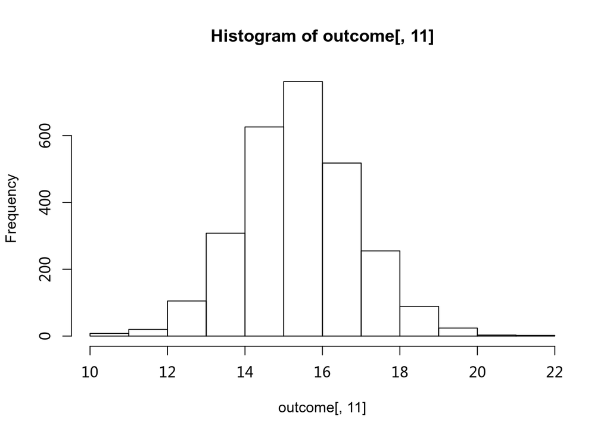

```r
hist(outcome[, 11])
```

## Finding the best hospital in a state

Write a function called best that take two arguments: the 2-character abbreviated name of a state and an outcome name. The function reads the outcome-of-care-measures.csv file and returns a character vector with the name of the hospital that has the best (i.e. lowest) 30-day mortality for the specified outcome in that state. The hospital name is the name provided in the Hospital.Name variable. The outcomes can be one of “heart attack”, “heart failure”, or “pneumonia”. Hospitals that do not have data on a particular outcome should be excluded from the set of hospitals when deciding the rankings.

```r
best <- function(state, outcome) {
  data <- read.csv("outcome-of-care-measures.csv", colClasses = "character")
  data <- data[,c(2,7,11,17,23)]
  name <- c('hispitol',"state","heart attack","heart failure","pneumonia")
  if (!state %in% unique(data[,2])) {
    stop("invalid state")
  }
  if (!outcome %in% name[3:5]) {
    stop("invalid outcome")
  }
  selected_data <- data[,c(1,2,which(name==outcome))]
  selected_data[,3]<-suppressWarnings(as.numeric(selected_data[,3]))
  selected_data=selected_data[selected_data$State==state & !is.na(selected_data[,3]),]
  ordered_data=selected_data[order(selected_data[,3],selected_data[,1]),]
  ordered_data[1,1]
}
```

test the best function:

```r
best("TX", "heart attack")
```

```
## [1] "CYPRESS FAIRBANKS MEDICAL CENTER"
```

```r
best("TX", "heart failure")
```

```
## [1] "FORT DUNCAN MEDICAL CENTER"
```

```r
best("MD", "heart attack")
```

```
## [1] "JOHNS HOPKINS HOSPITAL, THE"
```

```r
best("MD", "pneumonia")
```

```
## [1] "GREATER BALTIMORE MEDICAL CENTER"
```

```r
#best("BB", "heart attack")
#best("NY", "hert attack")
```

## Ranking hospitals by outcome in a state

Write a function called rankhospital that takes three arguments: the 2-character abbreviated name of a state (state), an outcome (outcome), and the ranking of a hospital in that state for that outcome (num). The function reads the outcome-of-care-measures.csv file and returns a character vector with the name of the hospital that has the ranking specified by the num argument.

```r
rankhospital <- function(state, outcome, num = "best") {
  data <- read.csv("outcome-of-care-measures.csv", colClasses = "character")
  data <- data[,c(2,7,11,17,23)]
  name <- c('hispitol',"state","heart attack","heart failure","pneumonia")
  if (!state %in% unique(data[,2])) {
    stop("invalid state")
  }
  if (!outcome %in% name[3:5]) {
    stop("invalid outcome")
  }
  selected_data <- data[,c(1,2,which(name==outcome))]
  selected_data[,3]<-suppressWarnings(as.numeric(selected_data[,3]))
  selected_data=selected_data[selected_data$State==state & !is.na(selected_data[,3]),]
  ordered_data=selected_data[order(selected_data[,3],selected_data[,1]),]
  if (num=='best'){
    num=1
  } else if (num=='worst'){
    num=nrow(ordered_data)
  } else if (is.numeric(num)) {
    num=round(num)
  } else {
    stop('invalid num')
  }
  ordered_data[num,1]
}
```

test the rankhospital function

```r
rankhospital("TX", "heart failure", 4)
```

```
## [1] "DETAR HOSPITAL NAVARRO"
```

```r
rankhospital("MD", "heart attack", "worst")
```

```
## [1] "HARFORD MEMORIAL HOSPITAL"
```

```r
rankhospital("MN", "heart attack", 5000)
```

```
## [1] NA
```

## Ranking hospitals in all states

Write a function called rankall that takes two arguments: an outcome name (outcome) and a hospital rank- ing (num). The function reads the outcome-of-care-measures.csv file and returns a 2-column data frame containing the hospital in each state that has the ranking specified in num. For example the function call rankall(“heart attack”, “best”) would return a data frame containing the names of the hospitals that are the best in their respective states for 30-day heart attack death rates. The function should return a value for every state (some may be NA). The first column in the data frame is named hospital, which contains the hospital name, and the second column is named state, which contains the 2-character abbreviation for the state name. Hospitals that do not have data on a particular outcome should be excluded from the set of hospitals when deciding the rankings.

```r
rankall <- function(outcome, num = "best") {
  source('rankhospital.R')
  temp_data <- read.csv("outcome-of-care-measures.csv", colClasses = "character")
  states <- sort(unique(temp_data$State))
  result_df=data.frame(sapply(states,function(x) rankhospital(x,outcome,num)))
  result_df['state']=row.names(result_df)
  names(result_df)=c('hospital','state')
  result_df
}
```

test the rankall function

```r
head(rankall("heart attack", 20), 10)
```

```
##                               hospital state
## AK                                <NA>    AK
## AL      D W MCMILLAN MEMORIAL HOSPITAL    AL
## AR   ARKANSAS METHODIST MEDICAL CENTER    AR
## AZ JOHN C LINCOLN DEER VALLEY HOSPITAL    AZ
## CA               SHERMAN OAKS HOSPITAL    CA
## CO            SKY RIDGE MEDICAL CENTER    CO
## CT             MIDSTATE MEDICAL CENTER    CT
## DC                                <NA>    DC
## DE                                <NA>    DE
## FL      SOUTH FLORIDA BAPTIST HOSPITAL    FL
```

```r
tail(rankall("pneumonia", "worst"), 3)
```

```
##                                      hospital state
## WI MAYO CLINIC HEALTH SYSTEM - NORTHLAND, INC    WI
## WV                     PLATEAU MEDICAL CENTER    WV
## WY           NORTH BIG HORN HOSPITAL DISTRICT    WY
```

```r
tail(rankall("heart failure"), 10)
```

```
##                                                             hospital state
## TN                         WELLMONT HAWKINS COUNTY MEMORIAL HOSPITAL    TN
## TX                                        FORT DUNCAN MEDICAL CENTER    TX
## UT VA SALT LAKE CITY HEALTHCARE - GEORGE E. WAHLEN VA MEDICAL CENTER    UT
## VA                                          SENTARA POTOMAC HOSPITAL    VA
## VI                            GOV JUAN F LUIS HOSPITAL & MEDICAL CTR    VI
## VT                                              SPRINGFIELD HOSPITAL    VT
## WA                                         HARBORVIEW MEDICAL CENTER    WA
## WI                                    AURORA ST LUKES MEDICAL CENTER    WI
## WV                                         FAIRMONT GENERAL HOSPITAL    WV
## WY                                        CHEYENNE VA MEDICAL CENTER    WY
```